# Home Credit Default Risk: Model Card

Author

Bradyn Jackson

Published

October 25, 2026

# Executive summary

**Recommendation.** Use the model to support, not replace, approve/decline decisions, declining applicants whose predicted probability of payment difficulty is above **13.5%**. Before deployment, refit the model with three changes to its inputs: remove family status; replace or constrain the implied-term feature (`CREDIT_TERM`, payment divided by loan), for example with the actual loan term or product type; and review the other 8 inputs flagged as hard to explain in Adverse action mapping. Adverse action notices must state the principal reasons actually behind a decline, so an input that cannot be explained to an applicant has to be fixed in the model, not filtered out of the letter. Put the monitoring in Limitations and risks in place at the same time.

**What the threshold means.** On training applicants scored by models that had not seen them, the cutoff approves 83.3% of applicants and cuts the default rate among those approved from 8.07% to 5.09%. It declines 47% of applicants who went on to default; 77% of those declined would have repaid, which is the trade that maximises profit at a 15% margin and 90% loss given default. Any cutoff from 13.0% to 15.0% earns within 0.1% of the maximum. If margins are much thinner the cutoff should be stricter (5.0% at a 5% margin).

**Expected financial impact.** Per 100,000 applicants, in the data’s currency, the cutoff earns 756M more than approving everyone, and 254M more than approving the same number of applicants on the external credit scores alone, with 502 fewer defaults. Against that benchmark it holds 9.8% less defaulted credit. Applied to Home Credit’s annualised impairment losses (EUR 1,720M), that is up to EUR 168M a year. The business impact analysis reported EUR 204M because it compared the two scores at the 5% default-rate target, where both approve the 75.0% the benchmark approves; this card compares them at the profit-optimal cutoff, where both approve 83.3%. Both figures are upper bounds, because Home Credit’s current process is stronger than the external scores alone. The BPS target of a 5% loss reduction (EUR 86M) needs 51% of that edge.

**Key caveats.**

- **Training data.** The model learned only from applicants Home Credit approved, and its target is payment difficulty, not loss.
- **Fairness.** Approval rates for applicants aged 20 to 35 fall below four-fifths of the oldest group’s, in line with their higher actual default rates. Marital status is still a model input; removing it costs 0.0008 AUC.
- **Explaining declines.** 96% of declined applicants have a legally sensitive or hard-to-explain factor among their top three reasons, most often the implied term (53%). The implied term is also the feature that has drifted most between training and test applicants (standardised mean difference +0.55). For 80% the main reason is the opaque external credit scores.
- **Cost assumptions.** Margin and loss given default are external benchmarks, not Home Credit’s own figures.

# Model details

- **Model:** gradient-boosted decision trees (XGBoost 3.2.1.1, fitted through tidymodels). The output is a probability of payment difficulty (`TARGET` = 1), not an approve/decline verdict.
- **Version:** `xgb_tuned_final_nogender`, fitted on 11 October 2026. This card was produced on 25 October 2026.
- **Training data:** all 307,511 applicants in `application_train` (Home Credit, via Kaggle, 2018), of whom 8.07% had payment difficulties. Only the application table is used. Of its 120 input columns, 17 mostly-empty ones are dropped. Engineered ratios, missing-value flags and one column per category level bring the model to 181 features.
- **Tuning:** a 20-point random search on a 5,000-applicant sample, the best three re-scored on a 20% comparison sample, and the tree count chosen from 500 to 2,000. No resampling for class imbalance: the modeling notebook compared down-sampling, up-sampling and SMOTE.

| Setting | Parameter | Value |
| --- | --- | --- |
| Number of trees | `trees` | 500 |
| Features considered at each split | `mtry` | 132 |
| Minimum node size | `min_n` | 38 |
| Maximum tree depth | `tree_depth` | 12 |
| Learning rate | `learn_rate` | 0.011034 |
| Minimum loss reduction to split | `loss_reduction` | 0.0000021619 |
| Share of applicants sampled per tree | `sample_size` | 0.8053 |

**Features excluded:**

- **`CODE_GENDER`**, for fairness: gender is a protected characteristic. Excluding it costs 0.0019 AUC.
- **The six supplementary tables** (credit bureau records, previous applications, payment histories) were not explored in the EDA and are not used.
- **Recommended before deployment: `NAME_FAMILY_STATUS`** (see Fairness analysis).

# Intended use

**Intended use.** The model ranks Home Credit consumer-loan applicants by their probability of payment difficulty. It supports approve/decline decisions made by underwriters and policy, and lets management set a risk appetite by moving the cutoff.

**Not intended for:**

- **Pricing** loans or setting interest rates.
- **Setting credit limits** or loan amounts.
- **Collections** or account management after a loan is made.
- **Applicants outside Home Credit’s markets**, or populations unlike the training data.
- **Fully automated decisions without reason codes:** every decline needs reasons the applicant can be given (see Adverse action mapping).

# Performance metrics

## Ranking accuracy (AUC)

| Measure | Training rows per fit | AUC |
| --- | --- | --- |
| Cross-validation, 20% comparison sample (3-fold) | 41,000 | 0.7479 |
| Out-of-fold, all training applicants (3-fold) | 205,000 | 0.7621 |
| Kaggle public leaderboard | 307,511 | 0.75608 |
| Kaggle private leaderboard | 307,511 | 0.75817 |

AUC is the chance that the model ranks a randomly chosen defaulter as riskier than a randomly chosen repayer (0.5 is random, 1.0 perfect). The out-of-fold and Kaggle scores (0.762 and 0.758) are above the comparison-sample score (0.748) because each fit learns from more applicants: about 205,000 or all 307,511, rather than 41,000.

## Calibration

The threshold analysis below treats each predicted default probability as a real probability. That only holds if the predictions are calibrated: among applicants given a predicted risk of 10%, about 10% should default.

| Fold | Applicants | Mean predicted default | Actual default rate |
| --- | --- | --- | --- |
| Fold 1 | 102,504 | 7.98% | 8.07% |
| Fold 2 | 102,504 | 8.03% | 8.07% |
| Fold 3 | 102,503 | 8.08% | 8.07% |

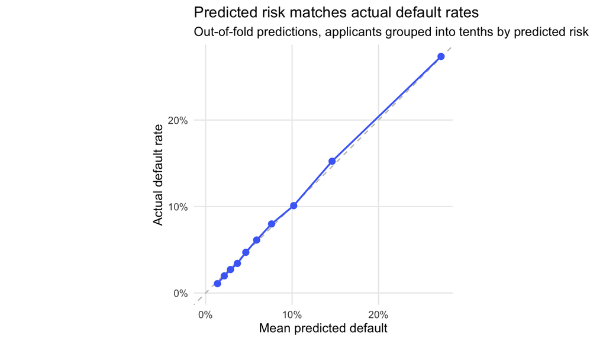

Across the ten risk groups, predicted and actual default rates differ by at most 0.61 percentage points, and the mean prediction in each fold is within 0.09 percentage points of the actual rate. Predicted probabilities can be read as probabilities.

## At the chosen threshold

The model declines applicants whose predicted default probability is above 13.5% (chosen in the next section). Here a “positive” is a predicted default, which means a decline.

| Measure | Value |
| --- | --- |
| Approval rate | 83.3% |
| Default rate among approved applicants | 5.1% |
| Precision: share of declined applicants who would have defaulted | 23.0% |
| Recall: share of all defaulters the model declines | 47.4% |

Per 100,000 applicants:

| Actual outcome | Approved | Declined | Total |
| --- | --- | --- | --- |
| Would have defaulted | 4,245 | 3,828 | 8,073 |
| Would have repaid | 79,087 | 12,840 | 91,927 |

The overall default rate is 8.07%. Approving at this threshold lowers that to 5.09% among approved applicants, while declining 16.7% of applicants. Most declined applicants (77%) would have repaid: that is the price of catching 47% of defaulters, and the threshold analysis shows it is the profit-maximising trade.

# Decision threshold analysis

## Break-even rule

Approving a loan of principal $C$ earns the margin $m \times C$ if it is repaid and loses $\text{LGD} \times C$ if it defaults. With predicted default probability $p$, the expected profit is

$$(1 - p)\, m\, C \;-\; p \cdot \text{LGD} \cdot C,$$

which is positive while

$$p \;<\; \frac{m}{m + \text{LGD}}.$$

Margin is net interest margin rather than net profit, because the threshold decides the *marginal* loan, and most operating cost does not change with one more approval. The thin-margin scenario covers the view that it does.

| Input | Base | Sensitivity | Source |
| --- | --- | --- | --- |
| Margin on a repaid loan (share of principal) | 15% | 5%, 10%, 20% | Home Credit B.V. FY2018 results: net interest margin 15.8% (homecredit.net, results announcement, 28 Jun 2019). BPS Q1 2019: net interest income EUR 889M on EUR 18,755M loans, about 19% annualised. |
| Loss given default, LGD (share of principal) | 90% | 45%, 70%, 95% | Typical unsecured consumer LGD about 90% (Vergent LMS, “Loss Given Default”); FTC (2013), “The Structure and Practices of the Debt Buying Industry”: charged-off debt sold for about 4 cents per dollar … |
| Recovery rate | 10% | = 1 - LGD | As above. |

| Scenario | Margin | LGD | Break-even predicted default |
| --- | --- | --- | --- |
| Base | 15% | 90% | 14.3% |
| Lenient recovery | 15% | 45% | 25.0% |
| Thin margin | 5% | 90% | 5.3% |
| High margin | 20% | 90% | 18.2% |

## Profit by cutoff

The rule above judges one loan at a time. To check it against actual outcomes, every training applicant is approved if their out-of-fold predicted default is at or below a cutoff, and the profit is totalled from what actually happened:

$$\text{profit} \;=\; m \sum_{\text{approved, repaid}} C \;-\; \text{LGD} \sum_{\text{approved, defaulted}} C,$$

using each loan’s raw `AMT_CREDIT` (in the data’s currency, not converted), for cutoffs from 2.0% to 40% in steps of 0.5 points, per 100,000 applicants.

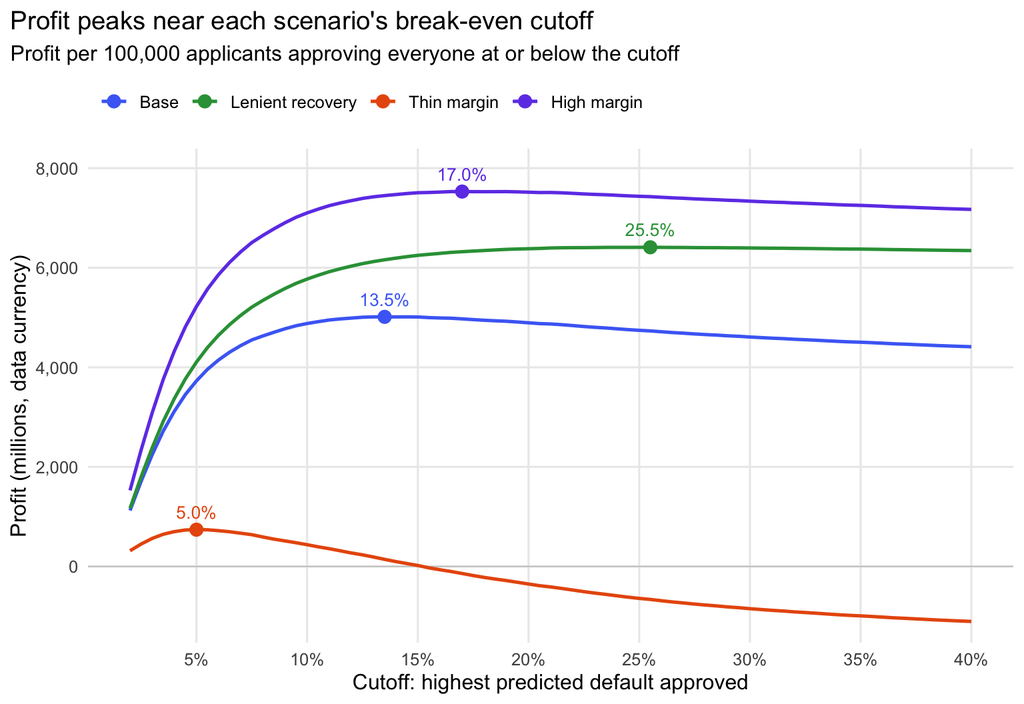

| Scenario | Break-even | Optimal cutoff | Approval rate | Default rate among approved | Profit per 100k | vs approve everyone |
| --- | --- | --- | --- | --- | --- | --- |
| Base | 14.3% | 13.5% | 83.3% | 5.09% | 5,013M | +756M |
| Lenient recovery | 25.0% | 25.5% | 95.5% | 6.81% | 6,410M | +127M |
| Thin margin | 5.3% | 5.0% | 48.2% | 2.70% | 739M | +2,021M |
| High margin | 18.2% | 17.0% | 88.7% | 5.74% | 7,529M | +502M |

In every scenario the empirical optimum lands within 1.2 points of the break-even rule, as calibrated predictions should. The base-case curve is flat near its peak: every cutoff from 13.0% to 15.0% earns within 0.1% of the maximum, so the exact cutoff matters less than being in that range.

## Sensitivity

The optimal cutoff for each combination of margin and LGD:

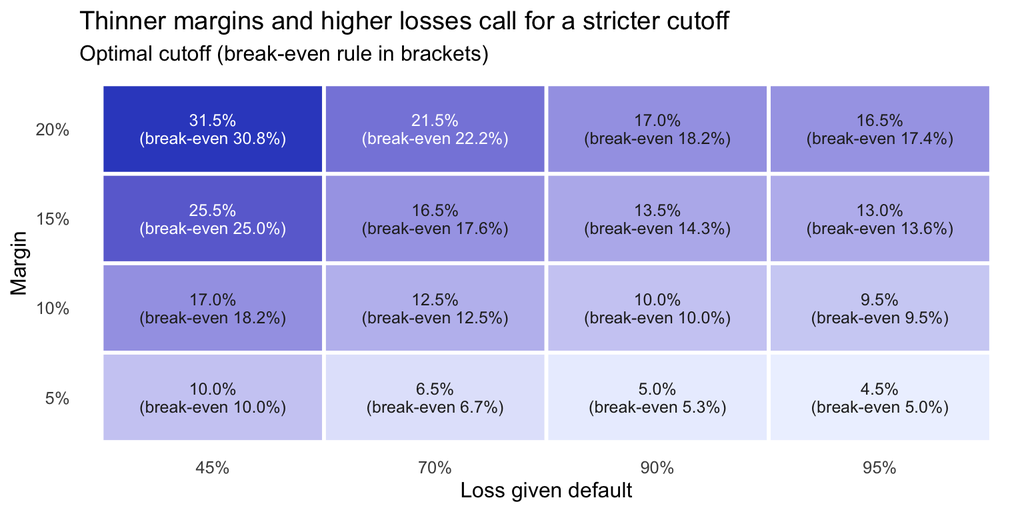

## Comparison with the 5% risk-appetite cutoff

| Rule | Cutoff | Approval rate | Default rate among approved | Profit per 100k |
| --- | --- | --- | --- | --- |
| Profit-maximising (base case, chosen) | 13.5% | 83.3% | 5.09% | 5,013.1M |
| 5% default-rate target | 13.1% | 82.5% | 5.00% | 5,011.5M |

The business impact analysis set the cutoff from a risk appetite: approve as many applicants as possible while keeping the default rate among them at 5%, which gave a cutoff of 13.1%. The profit-maximising cutoff under the base case is 13.5%, within 0.4 points, and the 5% target earns 2M less per 100,000 applicants (0.03%). The two ways of setting the threshold agree.

**Chosen threshold: decline applicants with a predicted default probability above 13.5%.** It is the base-case optimum, rounded to the nearest 0.5 points, and it is used for every result in the rest of this card.

**Caveat.** Margin and LGD are applied to the full principal over the loan’s life. That ignores timing (interest is earned over months, losses arrive later), partial repayment before default, and discounting.

# Explainability

## Method

The model’s decisions are explained with **SHAP values**, computed with XGBoost’s built-in TreeSHAP. For each applicant, SHAP splits the predicted log-odds of default into one contribution per feature, measured against the model’s baseline for an average applicant. The contributions add up exactly to the applicant’s prediction.

The explanations use a random sample of 1,000 applicants from the **test set**: applicants the model never saw during training, as a new applicant would be. Their outcomes are unknown, so this section explains decisions but does not judge whether they were right. The final model’s predictions on the test set are spread like the out-of-fold predictions the threshold was set on, so the chosen cutoff applies to them:

Predicted default at percentiles of each distribution

|  | 10% | 25% | 50% | 75% | 90% |
| --- | --- | --- | --- | --- | --- |
| Out-of-fold (training applicants) | 1.8% | 2.9% | 5.2% | 10.1% | 18.1% |
| Final model (all test applicants) | 1.8% | 2.9% | 5.4% | 10.5% | 18.1% |
| Final model (1,000-applicant sample) | 1.8% | 2.7% | 5.2% | 9.6% | 18.6% |

## Most influential factors

Features that encode the same thing about the applicant are combined: age appears as birth date, age in years and age band; the external scores as each score plus their mean, minimum, maximum and count; a category as one column per level. Each bar below is one thing about the applicant.

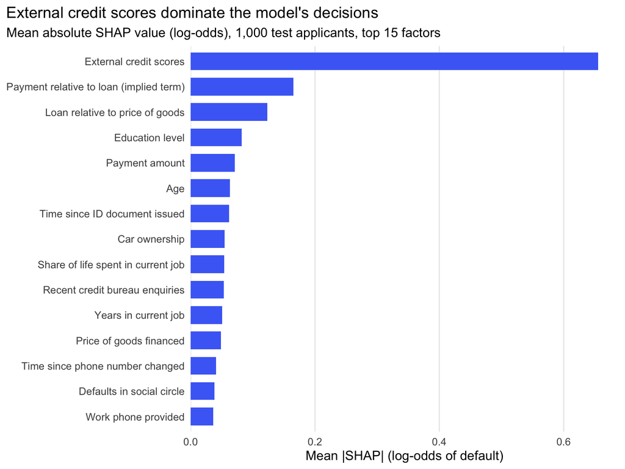

External credit scores account for 32% of the total, more than the next 7 factors combined.

The ten most influential individual features, one dot per applicant. Dots to the right raise predicted risk; colour shows the applicant’s value of that feature, from low to high:

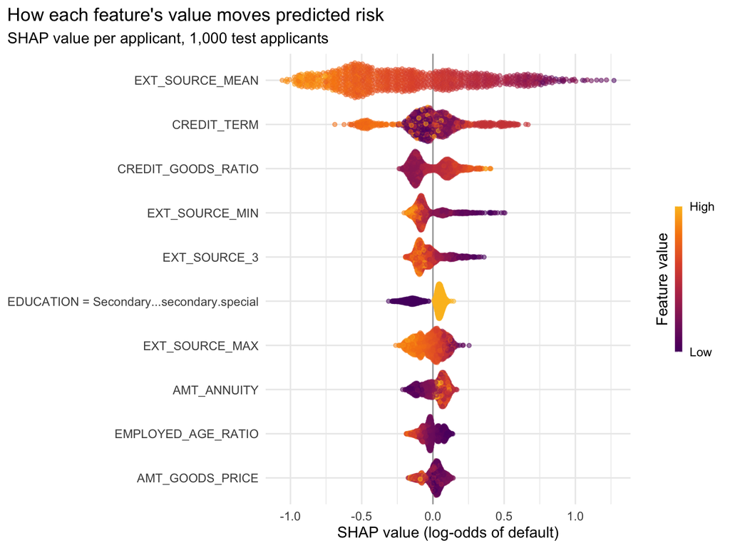

| Rank | Factor | Share of total \|SHAP\| | Direction |
| --- | --- | --- | --- |
| 1 | External credit scores | 32.0% | Higher external scores lower risk |
| 2 | Payment relative to loan (implied term) | 8.1% | Not monotone: some repayment schedules carry more risk than others |
| 3 | Loan relative to price of goods | 6.0% | Borrowing more than the goods cost raises risk |
| 4 | Education level | 4.0% | Secondary education or less raises risk; higher education lowers it |
| 5 | Payment amount | 3.5% | Larger payments raise risk |
| 6 | Age | 3.1% | Not monotone once other factors are known (see below) |
| 7 | Time since ID document issued | 3.0% | A recently issued ID raises risk |
| 8 | Car ownership | 2.7% | Owning a car lowers risk |
| 9 | Share of life spent in current job | 2.6% | A longer share of working life in the current job lowers risk |
| 10 | Recent credit bureau enquiries | 2.6% | No recent enquiries raises risk; zero includes applicants with no bureau record |

Age’s contribution is not monotone. Once the other factors are known, applicants in their 30s and 40s get the largest increase from age, while the youngest and oldest get a decrease:

| Age band | Applicants in sample | Mean age contribution (log-odds) |
| --- | --- | --- |
| [20,25) | 27 | -0.222 |
| [25,30) | 104 | -0.042 |
| [30,35) | 127 | 0.043 |
| [35,40) | 167 | 0.081 |
| [40,45) | 147 | 0.070 |
| [45,50) | 108 | 0.018 |
| [50,55) | 106 | 0.013 |
| [55,60) | 99 | -0.060 |
| [60,65) | 83 | -0.037 |
| [65,70] | 32 | -0.027 |

# Adverse action mapping

A declined applicant is entitled to the main reasons for the decision. Each factor below maps the condition that raises an applicant’s risk to the reason text a decline letter would use. The table covers the ten most influential factors and every factor that is among the top three reasons for any of the sampled applicants the model would decline. Flags mark factors that are legally sensitive, hard to explain to an applicant, or opaque third-party scores.

| Factor | Raises risk when | Reason given to applicant | Top-3 reason for (of 178 declined) | Flag |
| --- | --- | --- | --- | --- |
| External credit scores | Low external credit scores | Limited or weak credit history with external credit agencies | 154 | Opaque score: Third-party scores: reason text can only be generic |
| Payment relative to loan (implied term) | Payment-to-loan ratio in a higher-risk range | Requested loan term and repayment schedule | 95 | Hard to explain: The effect jumps between neighbouring terms |
| Loan relative to price of goods | Loan large relative to the price of the goods | Amount requested is high relative to the value of the purchase | 71 |  |
| Education level | Secondary or lower secondary education | Level of education | 7 | Sensitive: Proxy concern for protected characteristics |
| Payment amount | High payment amount | Payment amount requested is high | 26 |  |
| Age | Age band with higher model-estimated risk | Age | 49 | Sensitive: ECOA permits age in an empirically derived system only if it does not disadvantage elderly applicants |
| Time since ID document issued | Identity document issued recently | Length of time current identification has been held | 21 | Hard to explain |
| Car ownership | No car owned | Limited assets reported | 2 |  |
| Share of life spent in current job | Short time in current job relative to age | Length of employment is short relative to age | 10 |  |
| Recent credit bureau enquiries | No recent credit bureau enquiries or no bureau record | Limited recent credit history | 0 | Hard to explain: Zero mixes no enquiries with no bureau record (imputed) |
| Years in current job | Short time with current employer | Length of time with current employer | 4 |  |
| Price of goods financed | Low price of goods financed | Value of the goods being financed | 22 | Hard to explain: Overlaps with loan relative to price of goods |
| Time since phone number changed | Phone number changed recently | Recent change in contact information | 2 | Hard to explain |
| Defaults in social circle | People in the applicant’s social circle have defaulted | Credit performance of associated persons | 19 | Sensitive: Judges the applicant on other people’s repayment |
| Work phone provided | Work phone number provided | Work phone number provided on application | 19 | Hard to explain: Counter-intuitive direction |
| Payment relative to income | Payment high relative to income | Payment is high relative to income | 1 |  |
| Family status | Not married | Marital status | 1 | Sensitive: Marital status is an ECOA-prohibited basis |
| Occupation | Occupation with higher historical risk | Occupation | 7 |  |
| Region risk rating | Home region rated higher risk | Location of residence | 10 | Sensitive: Geography can proxy for protected characteristics |
| Income | Higher reported income for the loan and payment requested | Reported income | 3 | Hard to explain: Counter-intuitive direction |
| Employer type | Employer sector with higher historical risk | Type of employer | 2 |  |
| Time since registration changed | Registration changed recently | Length of time at registered address | 1 | Hard to explain |
| Home, registered and work address differ | Lives outside the city of registration | Residence differs from registered address | 8 | Hard to explain |

- **External credit scores** are third-party scores whose inputs Home Credit does not see, so the reason can only be generic.
- **Age** may be used in an empirically derived system under ECOA, but not to the detriment of elderly applicants. In this sample, the mean age contribution for applicants 60 and over is -0.034 log-odds (it lowers their predicted risk).
- **Education level** and **family status** are proxy and protected-basis concerns: marital status is a prohibited basis under ECOA, and both remain in the model.

## Examples

Three test applicants above the 13.5% cutoff, the applicants at the 25th, 50th and 75th percentile of predicted risk among those the model would decline:

**Applicant A** (test ID 227739): predicted default 15.7%

| Rank | Factor | Reason given | Contribution (log-odds) | Flag |
| --- | --- | --- | --- | --- |
| 1 | Payment relative to loan (implied term) | Requested loan term and repayment schedule | 0.59 | Hard to explain |
| 2 | Loan relative to price of goods | Amount requested is high relative to the value of the purchase | 0.13 |  |
| 3 | Payment amount | Payment amount requested is high | 0.13 |  |

**Applicant B** (test ID 199150): predicted default 19.9%

| Rank | Factor | Reason given | Contribution (log-odds) | Flag |
| --- | --- | --- | --- | --- |
| 1 | Payment relative to loan (implied term) | Requested loan term and repayment schedule | 0.51 | Hard to explain |
| 2 | Price of goods financed | Value of the goods being financed | 0.13 | Hard to explain |
| 3 | Age | Age | 0.11 | Sensitive |

**Applicant C** (test ID 166582): predicted default 26.8%

| Rank | Factor | Reason given | Contribution (log-odds) | Flag |
| --- | --- | --- | --- | --- |
| 1 | External credit scores | Limited or weak credit history with external credit agencies | 1.21 | Opaque score |
| 2 | Payment relative to loan (implied term) | Requested loan term and repayment schedule | 0.29 | Hard to explain |
| 3 | Work phone provided | Work phone number provided on application | 0.11 | Hard to explain |

178 of the 1,000 sampled applicants (17.8%) would be declined at the chosen cutoff. Of these:

- 96% have at least one legally sensitive or hard-to-explain factor among their top three reasons. The implied-term factor alone appears for 53%.
- 46% have a legally sensitive factor in their top three.
- For 19% the main reason is flagged. For 80% it is the external credit scores, which can only be explained generically.

Adverse action notices must state the principal reasons actually behind a decline, so flagged factors cannot be skipped or reworded at the letter stage. The fix belongs in the model: before deployment, replace or constrain the implied-term feature (for example with the actual loan term or product type) and review the other inputs flagged as hard to explain.

# Fairness analysis

`CODE_GENDER` is excluded from the model, which costs 0.0019 AUC on the comparison folds. Excluding a protected attribute does not by itself make outcomes fair: age and education remain in the model and the EDA found both correlate with protected characteristics. This section checks outcomes at the 13.5% cutoff on out-of-fold predictions.

The **adverse impact ratio** is a group’s approval rate divided by the highest group’s. Under the four-fifths rule, a ratio below 0.80 is evidence of adverse impact worth reviewing. The rule comes from US employment guidance (the EEOC’s Uniform Guidelines on Employee Selection Procedures); here it is a screening heuristic, not a legal test for lending. The actual default rate is shown next to it: a gap in approval that follows a gap in repayment is the model doing its job; a gap that does not is a problem.

## Gender

| Gender | Applicants | Actual default rate | Approval rate | Default rate among approved | Impact ratio | Four-fifths |
| --- | --- | --- | --- | --- | --- | --- |
| Female | 202,448 | 7.00% | 85.8% | 4.58% | 1.00 |  |
| Male | 105,059 | 10.14% | 78.6% | 6.18% | 0.92 |  |

4 applicants with gender recorded as `XNA` (unknown) are left out.

## Education

| Education | Applicants | Actual default rate | Approval rate | Default rate among approved | Impact ratio | Four-fifths |
| --- | --- | --- | --- | --- | --- | --- |
| Secondary / secondary special | 218,391 | 8.94% | 80.6% | 5.49% | 0.88 |  |
| Higher education | 74,863 | 5.36% | 91.4% | 3.95% | 1.00 |  |
| Incomplete higher | 10,277 | 8.48% | 84.0% | 5.64% | 0.92 |  |
| Lower secondary | 3,816 | 10.93% | 78.2% | 6.80% | 0.86 |  |
| Academic degree | 164 | 1.83% | 86.0% | 0.71% | 0.94 |  |

## Age

| Age band | Applicants | Actual default rate | Approval rate | Default rate among approved | Impact ratio | Four-fifths |
| --- | --- | --- | --- | --- | --- | --- |
| [20,25) | 12,233 | 12.29% | 64.7% | 6.83% | 0.66 | Below 0.80 |
| [25,30) | 32,953 | 11.13% | 71.3% | 6.34% | 0.73 | Below 0.80 |
| [30,35) | 39,476 | 10.27% | 75.2% | 5.66% | 0.77 | Below 0.80 |
| [35,40) | 42,855 | 8.97% | 80.5% | 5.47% | 0.82 |  |
| [40,45) | 41,406 | 7.83% | 84.9% | 5.09% | 0.87 |  |
| [45,50) | 35,193 | 7.42% | 85.1% | 4.75% | 0.87 |  |
| [50,55) | 34,997 | 6.67% | 88.7% | 4.68% | 0.90 |  |
| [55,60) | 33,097 | 5.54% | 92.8% | 4.35% | 0.95 |  |
| [60,65) | 27,425 | 5.28% | 94.9% | 4.55% | 0.97 |  |
| [65,70] | 7,876 | 3.66% | 98.1% | 3.48% | 1.00 |  |

## Family status

`NAME_FAMILY_STATUS` (marital status) is still in the model, and marital status is a prohibited basis under ECOA. Excluding it as well, with everything else in the final configuration unchanged, changes AUC on the comparison folds by:

| Fold | AUC with family status | AUC without | Cost of excluding |
| --- | --- | --- | --- |
| Fold 1 | 0.7506 | 0.7490 | 0.0016 |
| Fold 2 | 0.7425 | 0.7424 | 0.0002 |
| Fold 3 | 0.7505 | 0.7499 | 0.0006 |

The mean cost is 0.0008 AUC (3 of 3 folds lower without it), against 0.0019 for `CODE_GENDER`.

**Recommendation before deployment:** refit the final model without `NAME_FAMILY_STATUS`. The measured cost is small, and keeping a prohibited basis as a model input is a legal risk that the accuracy does not justify. This card describes the model as fitted, with family status included; the refit would need its own out-of-fold check before replacing it.

# Limitations and risks

- **Approved applicants only.** The training data holds only applicants Home Credit approved. How declined applicants would have repaid is unknown (no reject inference), so the model may misjudge applicant types the current process screens out.
- **`TARGET` marks payment difficulty, not loss.** Some flagged loans recover in full. The profit figures treat every default as a loss of 90% of principal.
- **Application table only.** Credit bureau history, previous applications and payment histories are not used. They may hold signal the model misses.
- **Data context.** One lender’s applicants, circa 2018. Amounts are in the data’s own currency, not converted, so financial figures per 100,000 applicants are in that currency. Only the BPS scaling is in euros.
- **Drift between training and test applicants.** Test loans are smaller relative to income and carry shorter implied terms. A standardised mean difference above 0.1 is worth a closer look:

| Feature | Train median | Test median | Standardised mean difference |  |
| --- | --- | --- | --- | --- |
| `CREDIT_TERM` | 0.05 | 0.0613 | 0.55 | Above 0.1 |
| `CREDIT_INCOME_RATIO` | 3.28 | 2.67 | -0.33 | Above 0.1 |
| `AMT_CREDIT` | 514,000 | 450,000 | -0.22 | Above 0.1 |
| `CREDIT_GOODS_RATIO` | 1.12 | 1.13 | 0.07 |  |
| `ANNUITY_INCOME_RATIO` | 0.163 | 0.165 | 0.02 |  |
| `EXT_SOURCE_MEAN` | 0.525 | 0.52 | -0.02 |  |
| `AGE_YEARS` | 43.1 | 43.2 | 0.01 |  |

- **Heavy reliance on external scores.** External credit scores carry 32% of the model’s SHAP importance, but their inputs are unknown to Home Credit. `EXT_SOURCE_1` is missing for 56% of applicants, and 172 have no external score at all.
- **Proxies for protected traits.** Gender is excluded, but age, education, marital status, region and social-circle defaults remain inputs. Approval rates for applicants aged 20 to 35 fall below the four-fifths line.
- **Bureau enquiries: missing counted as zero.** 14% of applicants have no bureau-enquiry record (AMT_REQ_CREDIT_BUREAU_QRT and the other enquiry counts are missing). Data preparation filled these with the median, 0, so “no enquiries” mixes in “no bureau record”. The two groups default at different rates (10.3% with no record, 7.8% with zero recorded enquiries). This is a data-preparation issue to fix in a refit, for example with a missing-value flag.
- **Legal reference.** The legal flags in this card use the US Equal Credit Opportunity Act (ECOA) as the reference. Home Credit’s markets have their own consumer-lending and anti-discrimination rules, which a deployment review would need to apply.
- **Cost assumptions are external benchmarks.** The 15% margin and 90% loss given default come from published figures and industry norms, not Home Credit’s own loan-level economics. The chosen cutoff moves with them (see Sensitivity).

## Monitoring

Once deployed, the model should be checked regularly against these triggers:

- **Input drift:** standardised mean difference of the key features between recent applicants and the training data. Review above 0.1.
- **Calibration:** predicted against actual default rate by tenth of predicted risk, as outcomes mature. The threshold math depends on it.
- **Approval rates by group:** gender, education and age band, with impact ratios. Review any group below 0.80, or any change since deployment.
- **Decline reasons:** how often each reason, and each flagged factor, is cited.
- **Ranking:** AUC on matured loans against the 0.762 out-of-fold baseline.

# Use of AI

I used Claude in two ways. In chat, it researched the cost assumptions and their sources, wrote the brief for this card, and reviewed each stage of the output. In Claude Code, it wrote the R code and drafted the text. I reviewed and approved each analytic decision, including scoring SHAP on unseen test applicants and measuring the cost of excluding family status.

# Appendix: reproducibility

Every model result in this card was loaded from the modeling notebook’s caches; nothing was refit:

| Result | Cache file | Fitted |
| --- | --- | --- |
| xgb_tuning | data/cv_xgb_tuning.rds | 2026-10-11 10:19 |
| xgb_tuned_pre0_mod20_post0 | data/cv_xgb_tuned_pre0_mod20_post0.rds | 2026-10-11 10:19 |
| xgb_tuned_pre0_mod17_post0 | data/cv_xgb_tuned_pre0_mod17_post0.rds | 2026-10-11 10:20 |
| xgb_tuned_pre0_mod14_post0 | data/cv_xgb_tuned_pre0_mod14_post0.rds | 2026-10-11 10:21 |
| xgb_trees_500 | data/cv_xgb_trees_500.rds | 2026-10-11 11:17 |
| xgb_trees_1000 | data/cv_xgb_trees_1000.rds | 2026-10-11 11:18 |
| xgb_trees_1500 | data/cv_xgb_trees_1500.rds | 2026-10-11 11:19 |
| xgb_trees_2000 | data/cv_xgb_trees_2000.rds | 2026-10-11 11:21 |
| xgb_tuned_nogender | data/cv_xgb_tuned_nogender.rds | 2026-10-11 11:33 |
| xgb_tuned_nogender_nofamily | data/cv_xgb_tuned_nogender_nofamily.rds | 2026-10-23 20:56 |
| xgb_tuned_final_nogender | models/xgb_tuned_final_nogender.rds | 2026-10-11 11:35 |
| xgb_final_oof | data/cv_xgb_final_oof.rds | 2026-10-14 18:47 |